# Week 3 - Logistic regression

The dataset that we are using here is joined data set that contains student information, including student alcohol consumption. General information about the data set can be found [here](https://archive.ics.uci.edu/ml/datasets/Student+Performance).The following adjustments have been made:

- The variables not used for joining the two data have been combined by averaging (including the grade variables)
- ‘alc_use’ is the average of ‘Dalc’ and ‘Walc’
- ‘high_use’ is TRUE if ‘alc_use’ is higher than 2 and FALSE otherwise

Dataset variables:

```r
colnames(alc)
```

```
##  [1] "school"     "sex"        "age"        "address"    "famsize"
##  [6] "Pstatus"    "Medu"       "Fedu"       "Mjob"       "Fjob"
## [11] "reason"     "nursery"    "internet"   "guardian"   "traveltime"
## [16] "studytime"  "failures"   "schoolsup"  "famsup"     "paid"
## [21] "activities" "higher"     "romantic"   "famrel"     "freetime"
## [26] "goout"      "Dalc"       "Walc"       "health"     "absences"
## [31] "G1"         "G2"         "G3"         "alc_use"    "high_use"
```

## Hypothesis

The purpose of the analysis is to study the relationships between high/low alcohol consumption and some of the other variables in the data. Here I am choosing 4 variables and my hypothesis about their relationships with alcohol consumption.

1. **Pstatus** - parent’s cohabitation status (binary: ‘T’ - living together or ‘A’ - apart)  
   I’m interested to see if children of parents who live together drink less than those of parents living apart.  
   Hypothesis: Parents living apart → Higer alchocol consumption
2. **famrel** - quality of family relationships (numeric: from 1 - very bad to 5 - excellent)  
   Hypothesis: Bad quiality → Higer alchocol consumption
3. **freetime** - free time after school (numeric: from 1 - very low to 5 - very high)  
   Hypothesis: More freetime → Higer alchocol consumption
4. **goout** - going out with friends (numeric: from 1 - very low to 5 - very high)  
   Hypothesis: Going out with friends more often → Higer alchocol consumption

## Distributions

### Distributions of the chosen variables

First, here are distributions of the chosen variables:

```
## Observations: 382
## Variables: 5
## $ Pstatus  <fct> A, T, T, T, T, T, T, A, A, T, T, T, T, T, A, T, T, T,...
## $ famrel   <int> 4, 5, 4, 3, 4, 5, 4, 4, 4, 5, 3, 5, 4, 5, 4, 4, 3, 5,...
## $ freetime <int> 3, 3, 3, 2, 3, 4, 4, 1, 2, 5, 3, 2, 3, 4, 5, 4, 2, 3,...
## $ goout    <int> 4, 3, 2, 2, 2, 2, 4, 4, 2, 1, 3, 2, 3, 3, 2, 4, 3, 2,...
## $ high_use <lgl> FALSE, FALSE, TRUE, FALSE, FALSE, FALSE, FALSE, FALSE...
```

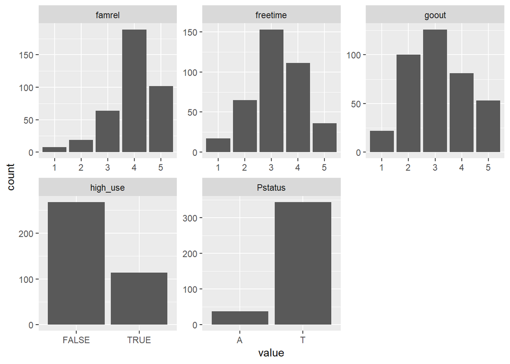

### Varibales relationships with high alcohol consumption:

Now we’ll explore varibales relationships with high alcohol consumption:

1. Parent’s cohabitation status and high alchocol use

```
## # A tibble: 4 x 4
## # Groups:   Pstatus [2]
##   Pstatus high_use     n  freq
##   <fct>   <lgl>    <int> <dbl>
## 1 A       FALSE       26 0.684
## 2 A       TRUE        12 0.316
## 3 T       FALSE      242 0.703
## 4 T       TRUE       102 0.297
```

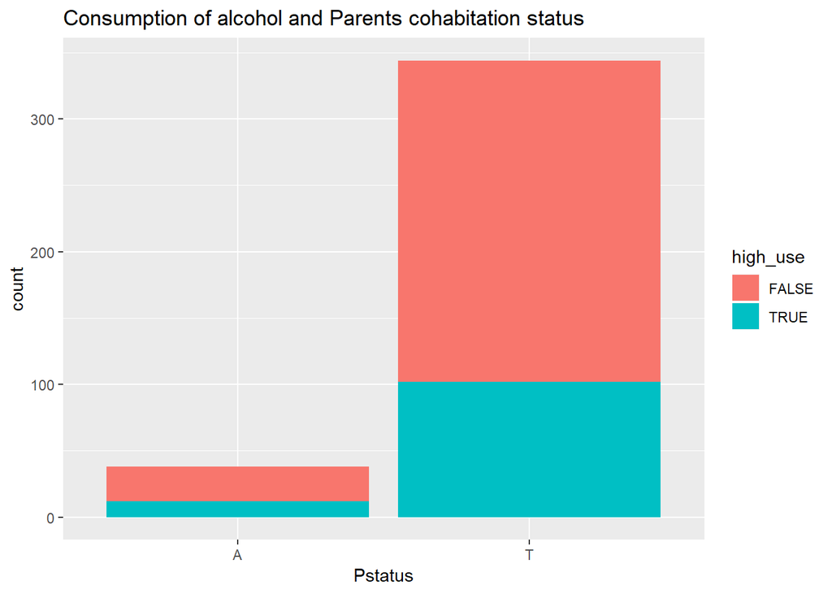

Only 31.6% of students whose parents live apart and 29.7% of those whose parents live together have high alchocol consumption. The differnce between these two groups is not very big, thus my hypothesis was wrong.

2. Quality of family relationships and high alchocol use

```
## # A tibble: 10 x 4
## # Groups:   famrel [5]
##    famrel high_use     n  freq
##     <int> <lgl>    <int> <dbl>
##  1      1 FALSE        6 0.75
##  2      1 TRUE         2 0.25
##  3      2 FALSE       10 0.526
##  4      2 TRUE         9 0.474
##  5      3 FALSE       39 0.609
##  6      3 TRUE        25 0.391
##  7      4 FALSE      135 0.714
##  8      4 TRUE        54 0.286
##  9      5 FALSE       78 0.765
## 10      5 TRUE        24 0.235
```

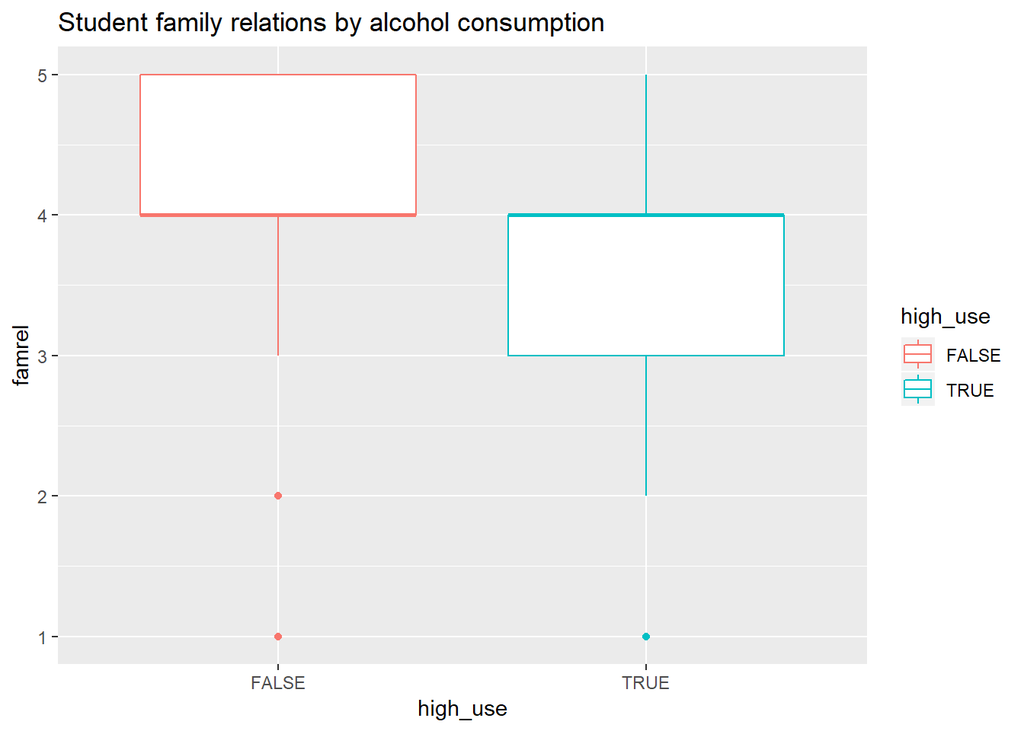

As assumed, students with better family relationships have smaller alchocol consumption.

3. Free time after school and high alchocol use

```
## # A tibble: 10 x 4
## # Groups:   freetime [5]
##    freetime high_use     n  freq
##       <int> <lgl>    <int> <dbl>
##  1        1 FALSE       15 0.882
##  2        1 TRUE         2 0.118
##  3        2 FALSE       49 0.754
##  4        2 TRUE        16 0.246
##  5        3 FALSE      113 0.739
##  6        3 TRUE        40 0.261
##  7        4 FALSE       70 0.631
##  8        4 TRUE        41 0.369
##  9        5 FALSE       21 0.583
## 10        5 TRUE        15 0.417
```

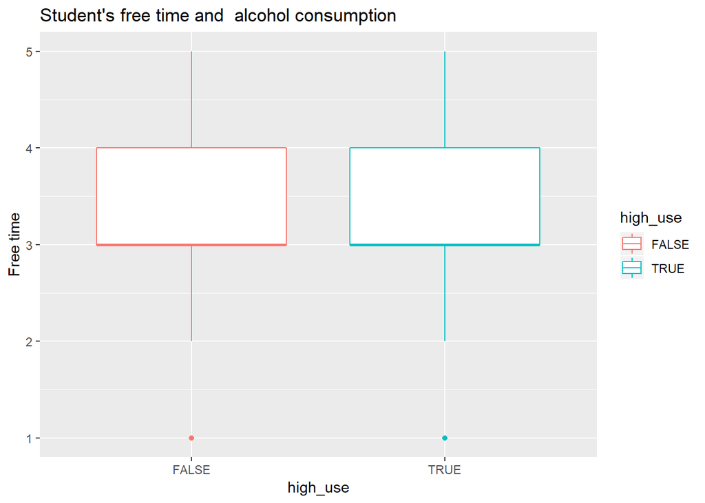

4. Going out with friends and high alchocol use

```
## # A tibble: 10 x 4
## # Groups:   goout [5]
##    goout high_use     n  freq
##    <int> <lgl>    <int> <dbl>
##  1     1 FALSE       19 0.864
##  2     1 TRUE         3 0.136
##  3     2 FALSE       84 0.84
##  4     2 TRUE        16 0.16
##  5     3 FALSE      103 0.817
##  6     3 TRUE        23 0.183
##  7     4 FALSE       41 0.506
##  8     4 TRUE        40 0.494
##  9     5 FALSE       21 0.396
## 10     5 TRUE        32 0.604
```

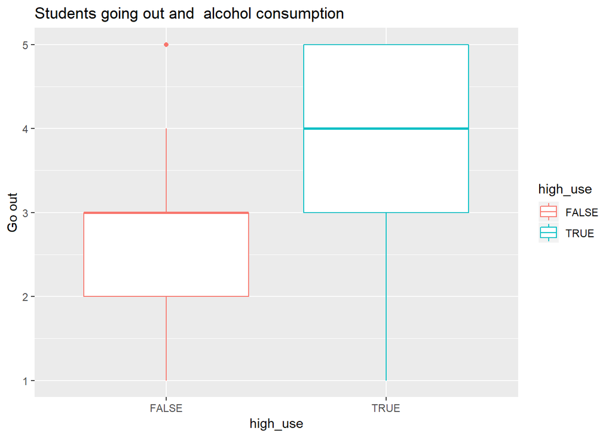

Students that go out with thier firends a lot, have higher alchocol consumption. This confirms the hypothesis.

## Logistic regression

#### The model

Now we’ll use logistic regression to statistically explore the relationship between the chosen variables and the binary high/low alcohol consumption variable as the target variable.

Here is the summary of the fitted model:

```r
# print out a summary of the model
summary(m)
```

```
##
## Call:
## glm(formula = high_use ~ Pstatus + famrel + freetime + goout,
##     family = "binomial", data = alc)
##
## Deviance Residuals:
##     Min       1Q   Median       3Q      Max
## -1.6507  -0.7947  -0.5693   1.0025   2.4052
##
## Coefficients:
##             Estimate Std. Error z value Pr(>|z|)
## (Intercept)  -2.2734     0.7423  -3.063  0.00219 **
## PstatusT     -0.1093     0.4018  -0.272  0.78557
## famrel       -0.3875     0.1359  -2.852  0.00435 **
## freetime      0.1751     0.1334   1.312  0.18949
## goout         0.7473     0.1220   6.123 9.17e-10 ***
## ---
## Signif. codes:  0 '***' 0.001 '**' 0.01 '*' 0.05 '.' 0.1 ' ' 1
##
## (Dispersion parameter for binomial family taken to be 1)
##
##     Null deviance: 465.68  on 381  degrees of freedom
## Residual deviance: 406.34  on 377  degrees of freedom
## AIC: 416.34
##
## Number of Fisher Scoring iterations: 4
```

The summary shows that Pstatus and freetime don’t have statistical relationship with target, which confirms the analysis above.

#### Coefficients of the model

Here we present the coefficients of the model as odds ratios and provide confidence intervals for them:

```
##                    OR      2.5 %    97.5 %
## (Intercept) 0.1029622 0.02316672 0.4298596
## PstatusT    0.8964576 0.41467616 2.0265025
## famrel      0.6787266 0.51825726 0.8845457
## freetime    1.1913437 0.91797013 1.5509857
## goout       2.1113265 1.67267689 2.7018310
```

Odds ratios are used to compare the relative odds of the occurrence of the outcome of interest (in this case high alcohol use), given exposure to the variables of interest.

We can see that exposure to famrel and PstatusT is associated with lower odds of outcome, while exposure to freetime and goout is associated with higher odds high alchocol use. Predictor PStatusT has the widest confidence interval.

## Predictive power of the model

According to the previous logistic regression model, only variables **famrel** and **goout** had a statistical relationship with high/low alcohol consumption. So here we create a new model, with only those two variables.

```r
m <- glm(high_use ~ famrel + goout, data = alc, family = "binomial")
summary(m)
```

```
##
## Call:
## glm(formula = high_use ~ famrel + goout, family = "binomial",
##     data = alc)
##
## Deviance Residuals:
##     Min       1Q   Median       3Q      Max
## -1.5448  -0.7518  -0.5252   0.9872   2.3530
##
## Coefficients:
##             Estimate Std. Error z value Pr(>|z|)
## (Intercept)  -2.0289     0.6148  -3.300 0.000966 ***
## famrel       -0.3667     0.1338  -2.740 0.006142 **
## goout         0.7922     0.1183   6.698 2.11e-11 ***
## ---
## Signif. codes:  0 '***' 0.001 '**' 0.01 '*' 0.05 '.' 0.1 ' ' 1
##
## (Dispersion parameter for binomial family taken to be 1)
##
##     Null deviance: 465.68  on 381  degrees of freedom
## Residual deviance: 408.12  on 379  degrees of freedom
## AIC: 414.12
##
## Number of Fisher Scoring iterations: 4
```

Here is a 2x2 cross tabulation of predictions versus the actual values and a graphic visualization of both the actual values and the predictions.

```
##         prediction
## high_use FALSE TRUE
##    FALSE   243   25
##    TRUE     68   46
```

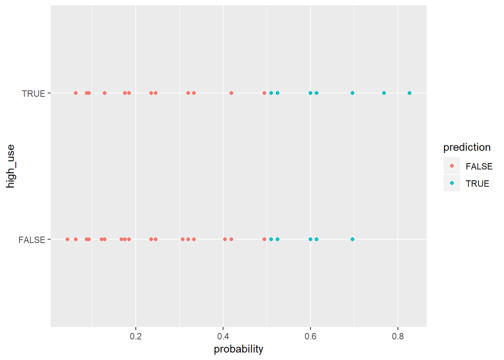

```
##         prediction
## high_use      FALSE       TRUE        Sum
##    FALSE 0.63612565 0.06544503 0.70157068
##    TRUE  0.17801047 0.12041885 0.29842932
##    Sum   0.81413613 0.18586387 1.00000000
```

Now we compute the total proportion of inaccurately classified individuals:

```
## [1] 0.2434555
```

## Bonus: Cross-validation

Here is error after a 10-fold cross-validation on my model:

```
## [1] 0.2591623
```